# multichainACF: ACF plots for multiple Markov chains

Medha Agarwal, Dootika Vats

2020-09-04

The `R` package `multichainACF` produces autocorrelation and autocovariance plots suitable for multiple Markov chains (with the same transition). Parallel implementations of Markov chains may concentrate in different parts of the state space particularly when the Markov chains are slow mixing. In such a situation running `acf` on each individual Markov chain can yield underestimates for the autocorrelation.

Following Agarwal and Vats (2020), we plot globally-centered ACF plots where the Markov chains are centered around the global mean from all chains.

## Demonstrative example

We demonstrate the striking difference in estimation in ACF plots. Consider a random-walk Metropolis-Hastings sampler for a univariate mixture of Gaussians target density. Let the target density be
$$f(x) = 0.7\,f(x; -5, 1) + 0.3\,f(x; 5, 0.5)\,,$$
where $f(x; a,b)$ is the density of a normal distribution with mean $a$ and variance $b$. We run two Markov chains with starting values distributed to the two modes. The trace plots below indicates that in the first $10^4$ steps, the chains do not jump modes so that both Markov chains yield significantly different estimates of the population mean, $\mu$. At $n = 10^5$, both Markov chains have traversed the state space reasonably and yield similar estimates of $\mu$.

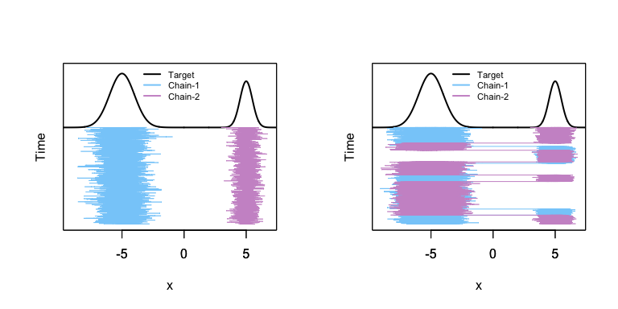

Simply, an ACF plot on any of the two chains for the shorter run of $10^4$ should indicate high correlation and what is popularly termed as “bad mixing”. However, the old ACF plots using `acf` give a false indication of the level of autocorrelation induced by the Markov chain kernel.

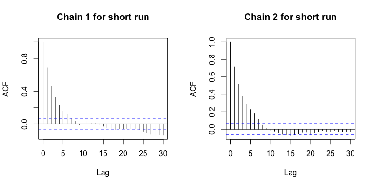

```r
par(mfrow = c(1,2))
acf(short_run[[1]], main = "Chain 1 for short run") # ACF of chain 1
acf(short_run[[2]], main = "Chain 2 for short run") # ACF of chain 2
```

Of course, once the Markov chains have jumped modes, the old `acf` function is finally able to assess the slow convergence.

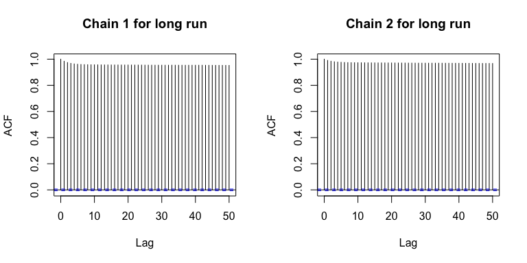

```r
par(mfrow = c(1,2))
acf(long_run[[1]], main = "Chain 1 for long run") # ACF of chain 1
acf(long_run[[2]], main = "Chain 2 for long run") # ACF of chain 2
```

### Globally centered ACF plots

The globally-centered ACF estimator accounts for the discrepancy in sample means between two chains leading to a far improved quality of estimation of autocorrelations even for shorter runs of the Markov chains. The ACF plots can be constructed using `globalACF` in the package. In addition to global centering, the package also provides a visual for assessing ACF plots for all Markov chains (for a specific component), with averaged ACF curves given in a solid line.

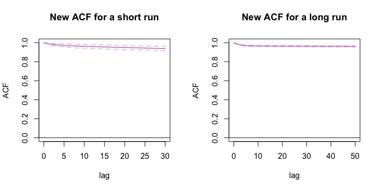

```r
library(multichainACF)

# Here is a new style of ACF plots for viewing all Markov chain ACFs with chains = 0
par(mfrow = c(1,2))
# same as acf() on chain1
globalACF(short_run, chains = 0, component = 1, col = "plum3", main = "New ACF for a short run")
globalACF(long_run, chains = 0, component = 1, col = "plum3", main = "New ACF for a long run")
```

Plots in the style of the traditional ACF plots are also possible by setting `avg = FALSE` and picking a particular chain.

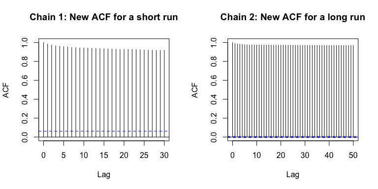

```r
par(mfrow = c(1,2))
# same as acf() on chain1
globalACF(short_run, chains = 1, component = 1, avg = FALSE, main = "Chain 1: New ACF for a short run")
globalACF(long_run, chains = 2, component = 1, avg = FALSE, main = "Chain 2: New ACF for a long run")
```

## References

Agarwal, Medha, and Dootika Vats. 2020. “Globally-Centered Autocovariances in MCMC.” *Arxiv*. https://arxiv.org/abs/2009.01799.